# R_Markdown_Valerie

Valerie Yu

2026-03-25

# Valerie’s R Assignment

Setting up the R Markdown and loading in R library.

## Part I

### *Data Inspection*

`fang_et_al_genotypes.txt`

- There are 2782 rows and 986 columns.
- The first 3 columns are `Sample_ID`, `JG_OTU`, and `Group`. Then the rest are SNP data (983).
- File size is 23124584 bytes
- Type is `list` and class is `data.frame`

`snp_position.txt`

- There are 983 rows and 15 columns.
- The columns are named `SNP_ID`, `Chromosome`, `Position`, etc.
- File size is 359384 bytes
- Type is `list` and class is `data.frame`

Note: I did visually inspect the dataset and used `head()`, but I commented it out so it didn’t spit out a bunch of lines in the final pdf/html.

```r
# Loading in data from "data" folder and looking at column names.
genotypes <- read_tsv("data/fang_et_al_genotypes.txt")
snp_position <- read_tsv("data/snp_position.txt")
# Inspecting the data
dim(genotypes) # 2782 rows  986 columns
```

```
## [1] 2782  986
```

```r
colnames(genotypes)[1:15] # variable names
```

```
##  [1] "Sample_ID" "JG_OTU"    "Group"     "abph1.20"  "abph1.22"  "ae1.3"
##  [7] "ae1.4"     "ae1.5"     "an1.4"     "ba1.6"     "ba1.9"     "bt2.5"
## [13] "bt2.7"     "bt2.8"     "Fea2.1"
```

```r
# head(genotypes) # 1st Sample_ID, 3rd Group
table(genotypes$Group)
```

```
##
## TRIPS ZDIPL ZLUXR ZMHUE ZMMIL ZMMLR ZMMMR ZMPBA ZMPIL ZMPJA ZMXCH ZMXCP ZMXIL
##    22    15    17    10   290  1256    27   900    41    34    75    69     6
## ZMXNO ZMXNT ZPERR
##     7     4     9
```

```r
  # maize count: ZMMIL 290, ZMMLR 1256, and ZMMMR 27 = 1573
  # teosinte count: ZMPBA 900, ZMPIL 41, and ZMPJA 34 = 975
object.size(genotypes) # 23124584 bytes
```

```
## 23124584 bytes
```

```r
typeof(genotypes) # list
```

```
## [1] "list"
```

```r
class(genotypes)
```

```
## [1] "spec_tbl_df" "tbl_df"      "tbl"         "data.frame"
```

```r
dim(snp_position) # 983 rows  15 columns
```

```
## [1] 983  15
```

```r
colnames(snp_position)[1:15] # variable names
```

```
##  [1] "SNP_ID"               "cdv_marker_id"        "Chromosome"
##  [4] "Position"             "alt_pos"              "mult_positions"
##  [7] "amplicon"             "cdv_map_feature.name" "gene"
## [10] "candidate/random"     "Genaissance_daa_id"   "Sequenom_daa_id"
## [13] "count_amplicons"      "count_cmf"            "count_gene"
```

```r
# head(snp_position) # 1st SNP_ID, 3rd Chromosome, 4th Position, etc.
table(snp_position$Chromosome) # 6 multiple and 27 unknown
```

```
##
##        1       10        2        3        4        5        6        7
##      155       53      127      107       91      122       76       97
##        8        9 multiple  unknown
##       62       60        6       27
```

```r
object.size(snp_position) # 359384 bytes
```

```
## 359384 bytes
```

```r
typeof(snp_position) # list
```

```
## [1] "list"
```

```r
class(snp_position)
```

```
## [1] "spec_tbl_df" "tbl_df"      "tbl"         "data.frame"
```

### *Data Processing*

`fang_et_al_genotypes.txt` First, I am cutting out the groups I need for maize and teosinte.

```r
# Filtering `fang_et_al_genotypes.txt`
maize_genotypes <- genotypes %>% filter(Group == "ZMMIL" |
                                        Group == "ZMMLR" |
                                        Group == "ZMMMR" )
teosinte_genotypes <- genotypes %>% filter(Group == "ZMPBA" |
                                           Group == "ZMPIL" |
                                           Group == "ZMPJA" )
# Checking: both result is 3, which is accurate
n_distinct(maize_genotypes$Group)
```

```
## [1] 3
```

```r
n_distinct(teosinte_genotypes$Group)
```

```
## [1] 3
```

Then I will transpose the genotype files so that columns become rows by using t() before joining.

```r
# MAIZE
t_maize_genotypes <- as.data.frame(t(maize_genotypes))
t_maize_genotypes <- t_maize_genotypes[-c(1,2,3),]
dim(t_maize_genotypes) # 983 rows just like snp_position
```

```
## [1]  983 1573
```

```r
# Add Sample_ID back
colnames(t_maize_genotypes) <- maize_genotypes$Sample_ID

# TEOSINTE
t_teosinte_genotypes <- as.data.frame(t(teosinte_genotypes))
t_teosinte_genotypes <- t_teosinte_genotypes[-c(1,2,3),]
dim(t_teosinte_genotypes) # 983 rows just like snp_position
```

```
## [1] 983 975
```

```r
# Add Sample_ID back
colnames(t_teosinte_genotypes) <- teosinte_genotypes$Sample_ID
```

Now I am cleaning snp_position and fixing the join key for genotype files. Assignment says files formated with 1st column is “SNP_ID”, the 2nd column is “Chromosome”, the 3rd column is “Position”, and subsequent columns are genotype data from either maize or teosinte individuals.”

https://stackoverflow.com/questions/29511215/how-can-i-convert-row-names-into-the-first-column

```r
# Clean snp_position. We only want column 1, 3, 4
cleaned_snp_position <- select(snp_position,
                               "SNP_ID", "Chromosome", "Position")
# I don't have SNP_ID column name from genotype data so here I add it.
t_maize_genotypes <- tibble::rownames_to_column(t_maize_genotypes, "SNP_ID")
t_teosinte_genotypes <- tibble::rownames_to_column(t_teosinte_genotypes, "SNP_ID")
```

Joining snp_position to both of these genotype files.

https://r4ds.hadley.nz/joins.html

```r
# MAIZE
joined_maize <- left_join(
  x = t_maize_genotypes,
  y = cleaned_snp_position,
  by = "SNP_ID")
tail(names(joined_maize), 5) # it stuck it onto the end, lets move it to the front
```

```
## [1] "CU0201"     "S0215"      "CU0202"     "Chromosome" "Position"
```

```r
joined_maize <- joined_maize %>% select(SNP_ID, Chromosome, Position, everything())


# TEOSINTE
joined_teosinte <- left_join(
  x = t_teosinte_genotypes,
  y = cleaned_snp_position,
  by = "SNP_ID")
tail(names(joined_teosinte), 5) # it stuck it onto the end, lets move it to the front
```

```
## [1] "TIP-272A"   "TIP-356-A"  "TIP-512"    "Chromosome" "Position"
```

```r
joined_teosinte <- joined_teosinte %>% select(SNP_ID, Chromosome, Position, everything())
```

Now let’s check the new datasets : `joined_maize` and `joined_teosinte`

```r
unique(joined_maize$Chromosome) # we need to remove multiple and unknown
```

```
##  [1] "2"        "5"        "1"        "3"        "4"        "6"
##  [7] "9"        "8"        "multiple" "7"        "unknown"  "10"
```

```r
joined_maize2 <- filter(joined_maize,
                Chromosome != "multiple" & Chromosome != "unknown")
unique(joined_maize2$Chromosome) # gone!
```

```
##  [1] "2"  "5"  "1"  "3"  "4"  "6"  "9"  "8"  "7"  "10"
```

```r
unique(joined_teosinte$Chromosome) # we need to remove multiple and unknown
```

```
##  [1] "2"        "5"        "1"        "3"        "4"        "6"
##  [7] "9"        "8"        "multiple" "7"        "unknown"  "10"
```

```r
joined_teosinte2 <- filter(joined_teosinte,
                Chromosome != "multiple" & Chromosome != "unknown")
unique(joined_teosinte2$Chromosome)  # gone!
```

```
##  [1] "2"  "5"  "1"  "3"  "4"  "6"  "9"  "8"  "7"  "10"
```

Fixing position and removing positions that are not numeric, and hence can not be sorted by increasing position values.

```r
class(joined_maize2$Position) # character, should be numeric so I don't sort wrong
```

```
## [1] "character"
```

```r
cleaned_maize <- joined_maize2 %>%
  mutate(Position = as.numeric(Position)) %>%
  filter(!is.na(Position)) # removes rows without numeric positions
cleaned_teosinte <- joined_teosinte2 %>%
  mutate(Position = as.numeric(Position)) %>%
  filter(!is.na(Position)) # removes rows without numeric positions
```

This is how I would generate the final files for 1 chromosome.

```r
dim(cleaned_maize) # 1576 columns
```

```
## [1]  939 1576
```

```r
test_chr_1 <- cleaned_maize %>%
  filter(Chromosome == "1")
test_chr_1_increase <- test_chr_1 %>%
  arrange(Position) %>%
  mutate(across(4:1576, function(x){
    ifelse(x == "?/?", "?", x) # instructions say replace missing with ? in increasing
  })
  )

test_chr_1_decrease <- test_chr_1 %>%
  arrange(desc(Position))%>%
  mutate(across(4:1576, function(x){
    ifelse(x == "?/?", "-", x) # instructions say replace missing with - in decreasing
  })
  )
```

Creating a function to do all 10! I used the basic structure of running chr 1 alone to write a generalized function.

```r
final_files <- function (df, chr, name){

  chr_df <- df %>% filter(Chromosome == chr)
  chr_increase <- chr_df %>%
    arrange(Position) %>%
    mutate(across(-(1:3), function(x){
    ifelse(x == "?/?", "?", x)
  })
  )

  chr_decrease <- chr_df %>%
  arrange(desc(Position))%>%
  mutate(across(-(1:3), function(x){
    ifelse(x == "?/?", "-", x)
  })
  )
# write_csv(dataframe, output path should be final_results, delimiters)
# I need no spaces with it in the final_maize or final_teosinte folder which is inside the final_results folder.
# set up should be : final_results/final_maize/maize_chr1_increasing.csv
  # which means that the actual file names requires
    # name + _chr + "chr" (the actual value) + _increasg.csv
   write_csv(chr_increase, paste0("final_results/final_", name, "/",
                                  name, "_chr", chr,
                                  "_increasing.csv") )
   write_csv(chr_decrease, paste0("final_results/final_", name, "/",
                                  name, "_chr", chr,
                                  "_decreasing.csv") )

}
```

Using `for loop` since it’s fairly short?

```r
class(cleaned_maize$Chromosome) # characters
```

```
## [1] "character"
```

```r
for(chr in as.character(1:10)) {
  final_files(cleaned_maize, chr, "maize")
}

for(chr in as.character(1:10)) {
  final_files(cleaned_teosinte, chr, "teosinte")
}
```

## Part II Visualization

### *SNPs per chromosome*

**What is the distribution of SNPs on and across chromosomes?**

The graph below answers this question. From most to least number of SNPS are: Chromosome 1, 2, 5, 3, 7, 4, 6, 8, 9, 10.

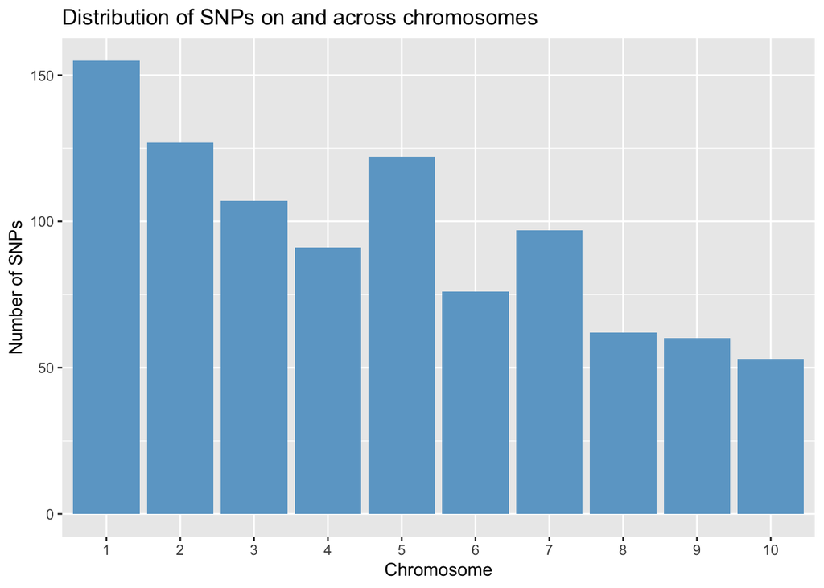

```r
# Unsure if we want Chromosome with multiple or unknown since they aren't numerically sortable.
# This gives us number of SNP sites on each chromosome 1 through 10.

dist_SNPs <- snp_position %>%
  filter(Chromosome != "multiple" & Chromosome != "unknown") %>%
  mutate(Chromosome = as.numeric(Chromosome)) %>% # keep having to make sure everything is numeric and not character
  mutate(Chromosome = factor(Chromosome, levels = 1:10)) %>%
  count(Chromosome)



ggplot(dist_SNPs, aes(x=Chromosome, y=n)) +
  geom_bar(stat = "identity", fill = "skyblue3") +
  labs (
    title = "Distribution of SNPs on and across chromosomes",
    x = "Chromosome",
    y = "Number of SNPs"
  )
```

```r
ggsave("graphs/PartIIQ1_Distribution_of_SNPs_on_and_across_chromosomes.pdf")
```

**Are there more SNP positions in maize or teosinte individuals?**

There are more polymorphic SNP positions in **teosinte** individuals.

I don’t know if I fully understood this. My initial code provided that they had the same amount of SNP positions. Here, I am looking for polymporphic SNPS. My thought process is to use `joined_maize2` after I removed multiple and unknown chromosomes.

```r
poly_maize <- apply(joined_maize2[, -(1:3)],1,
# we don't want the first 3 columns since that's not genotype data, and so given the data we want, for every row x we do...
              function (x) {
                x <- x[x != "?/?"]
# I don't want missing data because it gets in the way of sorting by unique
                length(unique(x)) > 1 })
# Checking if variation, if all the same the monomorphic
# view(poly_maize) # True for polymorphic, False for monomorphic!

joined_maize2$polymorphic <- poly_maize
# Tacking on a column to end of joined_maize

poly_maize <- joined_maize2  %>%
  filter(polymorphic)  %>%
  count(Chromosome)  %>%
  mutate(type = "maize")

# exact same thing for teosinte

poly_teosinte <- apply(joined_teosinte2[, -(1:3)],1,
              function (x) {
                x <- x[x != "?/?"]
                length(unique(x)) > 1 })
joined_teosinte2$polymorphic <- poly_teosinte

poly_teosinte <- joined_teosinte2  %>%
  filter(polymorphic)  %>%
  count(Chromosome)  %>%
  mutate(type = "teosinte")
```

Plot `teosinte` and `maize` now!

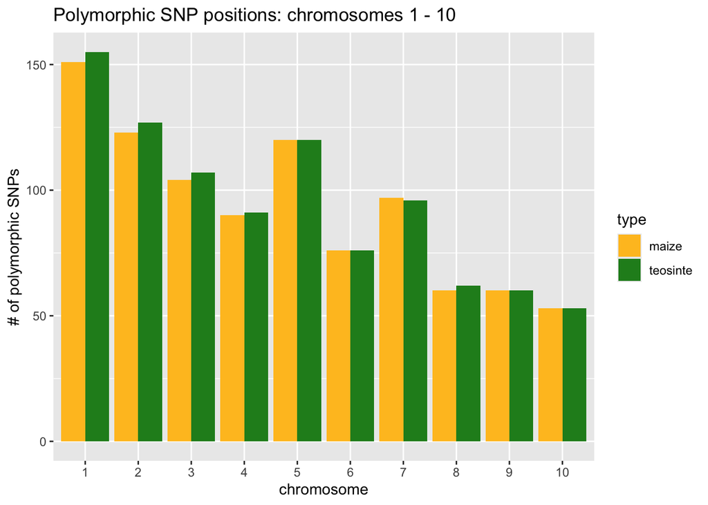

```r
poly_per_chr <- bind_rows(poly_maize, poly_teosinte)
#view(poly_per_chr)

poly_per_chr <- mutate(poly_per_chr, Chromosome = factor(Chromosome, levels = as.character(1:10)))

ggplot(poly_per_chr, aes(x = Chromosome, y = n, fill = type)) + geom_bar(stat = "identity", position = "dodge") + labs (
      title = "Polymorphic SNP positions: chromosomes 1 - 10",
      x = "chromosome",
      y = "# of polymorphic SNPs"
)  + scale_fill_manual(values = c("maize" = "goldenrod1", "teosinte" = "forestgreen"))
```

```r
ggsave("graphs/PartIIQ1_Polymorphic_SNP_positions_chromosomes_1-10.pdf")
```

### *Missing data and amount of heterozygosity*

**What is the proportion of homozygous and heterozygous sites as well as missing data in each sample and each group?**

Maize

- missing 0.048
- homozygous 0.817
- heterozygous 0.134

Teosinte

- missing 0.044
- homozygous 0.745
- heterozygous 0.211

(this is from looking at `Plot 1 Maize and Teosinte combined`)

```r
# here I am sorting for missing, homozygous, and heterzygous by using substr() to see if the genotypes match and sum counts how many sites
homhetmis <- genotypes %>%
  mutate(
    missing = apply(select(., -(1:3)), 1,
                    function(x) sum(x == "?/?")),
# here we dont want ?/?, my logic is that I want first and second letters to match but there's a "/" so it's 1 and 3 string position
    homozygous = apply(select(., -(1:3)), 1,
                    function(x) sum(x != "?/?" & substr(x,1,1) == substr(x,3,3))),
    heterozygous = apply(select(., -(1:3)), 1,
                    function(x) sum(x != "?/?" & substr(x,1,1) != substr(x,3,3)))
    )

# now I'm totaling the sites and then dividing to normalize
homhetmis <- homhetmis %>%
  mutate(total = missing + homozygous + heterozygous,
         proportion_miss = missing / total,
         proportion_homo = homozygous / total,
         proportion_hete = heterozygous / total)

# now I need to check my dataframe and take what I need
select(homhetmis, Sample_ID, Group, proportion_miss, proportion_hete, proportion_homo)
```

| Sample_ID | Group | proportion_miss | proportion_hete | proportion_homo |
| --- | --- | --- | --- | --- |
| SL-15 | TRIPS | 0.337741607 | 0.020345880 | 0.6419125 |
| SL-16 | TRIPS | 0.350966429 | 0.022380468 | 0.6266531 |
| SL-11 | TRIPS | 0.245167854 | 0.045778230 | 0.7090539 |
| SL-12 | TRIPS | 0.272634791 | 0.048830112 | 0.6785351 |
| SL-18 | TRIPS | 0.322482197 | 0.025432350 | 0.6520855 |
| SL-2 | TRIPS | 0.329603255 | 0.022380468 | 0.6480163 |
| SL-4 | TRIPS | 0.331637843 | 0.025432350 | 0.6429298 |
| SL-6 | TRIPS | 0.327568667 | 0.028484232 | 0.6439471 |
| SL-7 | TRIPS | 0.322482197 | 0.023397762 | 0.6541200 |
| SL-5 | TRIPS | 0.324516785 | 0.023397762 | 0.6520855 |

[output cut: 2772 more lines]

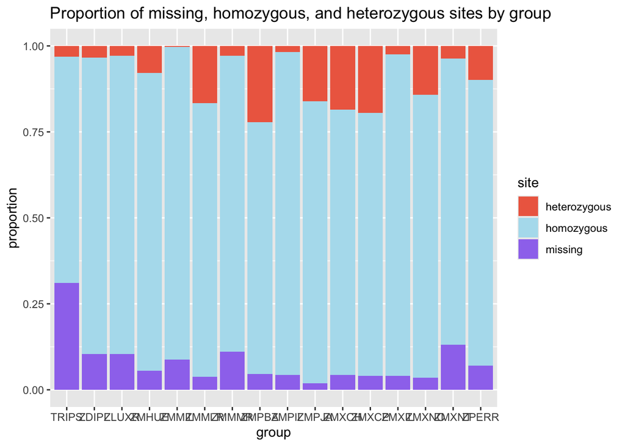

```r
# now putting Samples into their Group
group_homhetmis <- homhetmis %>%
  group_by(Group) %>%
  summarise(
    mean_miss = mean(proportion_miss),
    mean_hete = mean(proportion_hete),
    mean_homo = mean(proportion_homo)
  )
# binding all together with column to indicate genotype category (in hindsight this is just long format)
plot_homhetmis <- bind_rows(
  group_homhetmis %>%
    select(Group, prop = mean_miss) %>%
  mutate(site = "missing"),

  group_homhetmis %>%
   select(Group, prop = mean_homo) %>%
  mutate(site = "homozygous"),

   group_homhetmis %>%
     select(Group, prop = mean_hete) %>%
  mutate(site = "heterozygous"))

# plot
ggplot(plot_homhetmis, aes(x = Group, y = prop, fill = site)) +
  geom_col(position = "fill") + labs(
    title = "Proportion of missing, homozygous, and heterozygous sites by group",
    x = "group",
    y = "proportion"
  ) +
#?scale_fill_manual
  scale_fill_manual(values = c("missing" = "mediumpurple2", "homozygous" = "lightblue2", "heterozygous" = "coral2"))
```

```r
ggsave("graphs/PartIIQ2_Proportion_of_missing,_homozygous,_and_heterozygous_sites_by_group.pdf")
```

**3 Plots added after reviews:** Plot 1 Maize and Teosinte combined

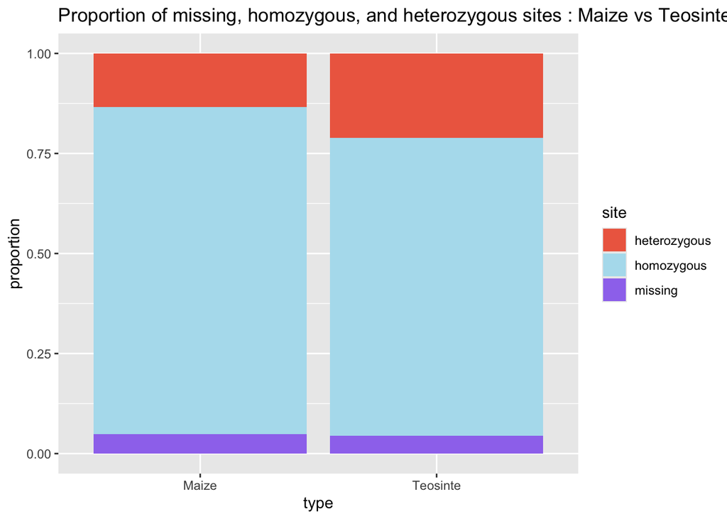

```r
# I realized that I may have misinterpreted this quesiton. Here is a second graph that includes only teosinte and maize groups.

homhetmis_M <- homhetmis %>% filter(Group == "ZMMIL" |
                                    Group == "ZMMLR" |
                                    Group == "ZMMMR" )
group_homhetmis_M <- homhetmis_M %>%
  summarise(
    mean_miss = mean(proportion_miss),
    mean_hete = mean(proportion_hete),
    mean_homo = mean(proportion_homo)
  )

homhetmis_T <- homhetmis %>% filter(Group == "ZMPBA" |
                                    Group == "ZMPIL" |
                                    Group == "ZMPJA" )
group_homhetmis_T <- homhetmis_T %>%
  summarise(
    mean_miss = mean(proportion_miss),
    mean_hete = mean(proportion_hete),
    mean_homo = mean(proportion_homo)
  )

# Combine via bind_rows
group_homhetmis_MT <- bind_rows(
  group_homhetmis_M %>% mutate (type = "Maize"),
  group_homhetmis_T %>% mutate (type = "Teosinte")
)

# Same as before
plot_homhetmis_MT <- bind_rows(
  group_homhetmis_MT  %>%
    select(type, prop = mean_miss) %>%
  mutate(site = "missing"),

  group_homhetmis_MT  %>%
   select(type, prop = mean_homo) %>%
  mutate(site = "homozygous"),

   group_homhetmis_MT  %>%
     select(type, prop = mean_hete) %>%
  mutate(site = "heterozygous"))

view(plot_homhetmis_MT)

# Plot 1 with combined
ggplot(plot_homhetmis_MT, aes(x = type, y = prop, fill = site)) +
  geom_col(position = "fill") + labs(
    title = "Proportion of missing, homozygous, and heterozygous sites : Maize vs Teosinte",
    x = "type",
    y = "proportion"
  ) +
#?scale_fill_manual
  scale_fill_manual(values = c("missing" = "mediumpurple2", "homozygous" = "lightblue2", "heterozygous" = "coral2"))
```

```r
ggsave("graphs/PartIIQ2_Maize_and_Teosinte_combined.pdf")
```

Plot 2 Maize and Teosinte groups

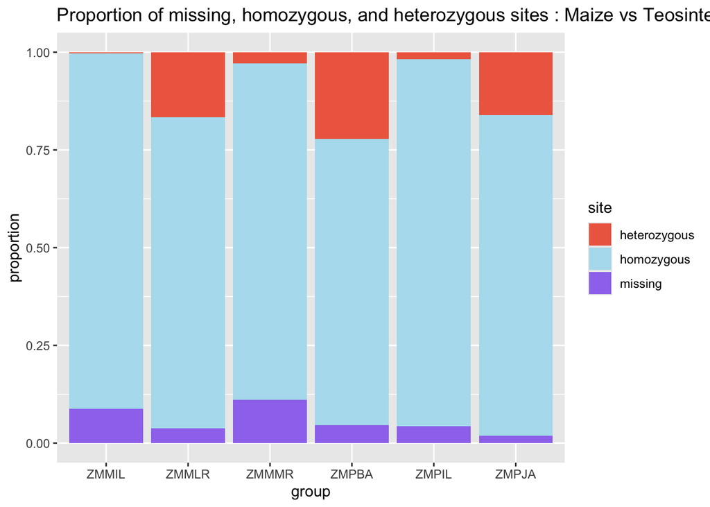

```r
# Most of this uses same logic as above, I added group_by(Group) though so I get the 3 groups each
group_homhetmis_M2 <- homhetmis_M %>%
  group_by(Group)%>%
  summarise(
    mean_miss = mean(proportion_miss),
    mean_hete = mean(proportion_hete),
    mean_homo = mean(proportion_homo)
  ) %>% mutate (type = "Maize")

group_homhetmis_T2 <- homhetmis_T %>%
  group_by(Group)%>%
  summarise(
    mean_miss = mean(proportion_miss),
    mean_hete = mean(proportion_hete),
    mean_homo = mean(proportion_homo)
  ) %>% mutate (type = "Teosinte")

group_homhetmis_MT2 <- bind_rows(group_homhetmis_M2, group_homhetmis_T2)

plot_homhetmis_MT2 <- bind_rows(
  group_homhetmis_MT2  %>%
    select(Group, type, prop = mean_miss) %>%
  mutate(site = "missing"),

  group_homhetmis_MT2  %>%
   select(Group, type, prop = mean_homo) %>%
  mutate(site = "homozygous"),

   group_homhetmis_MT2  %>%
     select(Group, type, prop = mean_hete) %>%
  mutate(site = "heterozygous"))

ggplot(plot_homhetmis_MT2, aes(x = factor(Group, levels = c("ZMMIL", "ZMMLR", "ZMMMR", # maize
"ZMPBA", "ZMPIL", "ZMPJA")), # teosinte
y = prop, fill = site)) +
  geom_col(position = "fill") + labs(
    title = "Proportion of missing, homozygous, and heterozygous sites : Maize vs Teosinte by group",
    x = "group",
    y = "proportion"
  ) +
#?scale_fill_manual
  scale_fill_manual(values = c("missing" = "mediumpurple2", "homozygous" = "lightblue2", "heterozygous" = "coral2"))
```

```r
# forcing order so it's maize 3 then teosinte 3
ggsave("graphs/PartIIQ2_Maize_and_Teosinte_groups.pdf")
```

Plot 3/4 Maize and Teosinte by sample

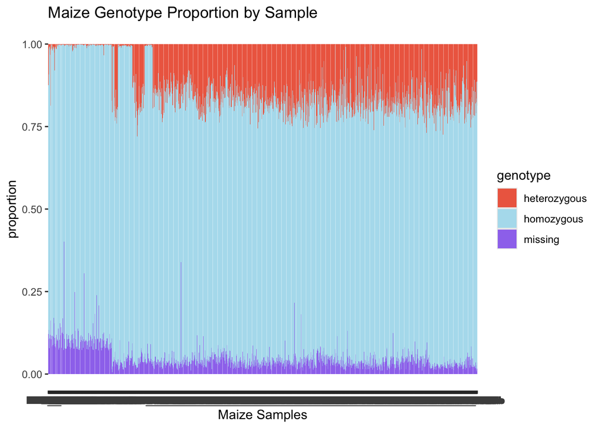

```r
samples_M <-homhetmis %>% filter (Group == "ZMMIL" |
                                  Group == "ZMMLR" |
                                  Group == "ZMMMR" ) %>%
  select(Sample_ID, proportion_hete,proportion_homo,proportion_miss) %>%
# using pivot_longer from wide format to long so easier to make stacked bars in ggplot, I think I was manually doing it with bind_rows earlier (messy)
  pivot_longer(cols = c(proportion_hete,proportion_homo,proportion_miss),
               names_to = "genotype",
               values_to = "proportion")
# naming genotype to either missing, homozygous, or heterozygous
samples_M <- samples_M  %>% mutate (genotype = case_when(
  genotype == "proportion_miss" ~"missing",
  genotype == "proportion_homo" ~"homozygous",
  genotype == "proportion_hete" ~"heterozygous"
))

samples_T <-  homhetmis %>% filter (Group == "ZMPBA" |
                                    Group == "ZMPIL" |
                                    Group == "ZMPJA" )%>%
  select(Sample_ID, proportion_hete,proportion_homo,proportion_miss) %>%
  pivot_longer(cols = c(proportion_hete,proportion_homo,proportion_miss),
               names_to = "genotype",
               values_to = "proportion")
# naming genotype to either missing, homozygous, or heterozygous
samples_T <- samples_T  %>% mutate (genotype = case_when(
  genotype == "proportion_miss" ~"missing",
  genotype == "proportion_homo" ~"homozygous",
  genotype == "proportion_hete" ~"heterozygous"
))
# Maize graph
ggplot(samples_M, aes(x = Sample_ID, y = proportion, fill = genotype)) +
  geom_col() + labs(
    title = "Maize Genotype Proportion by Sample",
    x = "Maize Samples",
    y = "proportion",
    fill = "genotype"
  )+scale_fill_manual(values = c("missing" = "mediumpurple2", "homozygous" = "lightblue2", "heterozygous" = "coral2"))
```

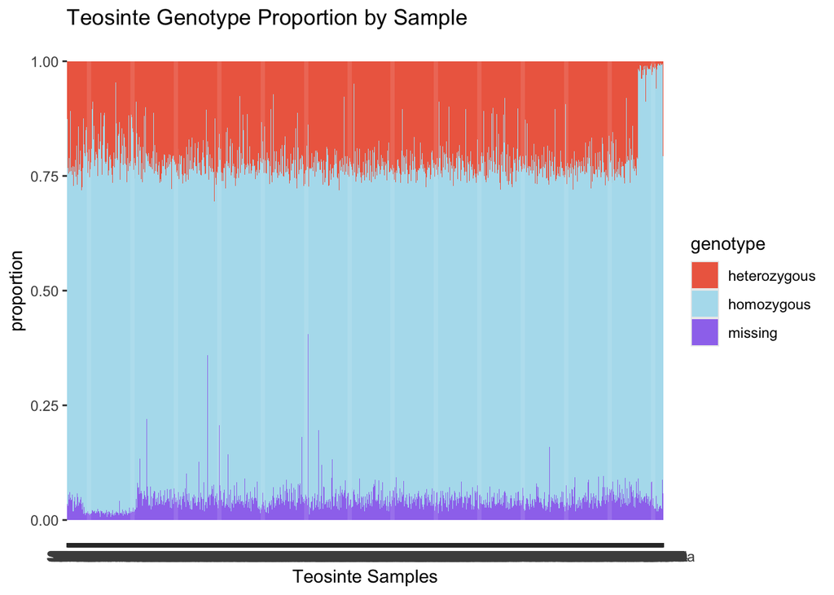

```r
ggsave("graphs/PartIIQ2_Maize_by_samples.pdf")
# Teosinte graph
ggplot(samples_T, aes(x = Sample_ID, y = proportion, fill = genotype)) +
  geom_col() + labs(
    title = "Teosinte Genotype Proportion by Sample",
    x = "Teosinte Samples",
    y = "proportion",
    fill = "genotype"
  )+scale_fill_manual(values = c("missing" = "mediumpurple2", "homozygous" = "lightblue2", "heterozygous" = "coral2"))
```

```r
ggsave("graphs/PartIIQ2_Teosinte_by_samples.pdf")
```

### *Your own visualization*

**Visualize one other feature of the dataset. The choice is up to you!**

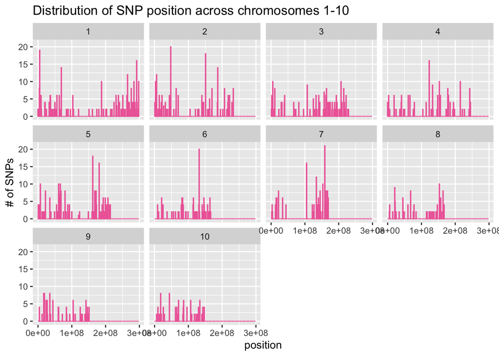

```r
# I am plotting the genomoic position of polymorphic sites.
# Originally I used joined_maize for the polymorphic work above
# Got errors and an NA so I switched above to joined_maize2, meaning this changed too.

plot_mazie_poly <- joined_maize2  %>%
  filter(polymorphic)  %>%

# I have to remove unknown and multiples again, they created an N/A column
  mutate(Dataset = "maize", Position = as.numeric(Position) ) %>%
  filter(!is.na(Position)) %>%

# Sorts alphanumerically again so....
  mutate(Chromosome = factor(Chromosome, levels = 1:10))
plot_teosinte_poly <- joined_teosinte2  %>%
  filter(polymorphic)  %>%
  mutate(Dataset = "teosinte", Position = as.numeric(Position) ) %>%
  filter(!is.na(Position)) %>%
  mutate(Chromosome = factor(Chromosome, levels = 1:10))
# combine them
plot_poly_position <- bind_rows(plot_mazie_poly, plot_teosinte_poly )

# increased binwidth, small numbers spit error
ggplot(plot_poly_position, aes(x=Position)) +
  geom_histogram(binwidth=1000000, fill = "black", color = "hotpink2") +
  facet_wrap( ~ Chromosome) +

  labs (
    title = "Distribution of SNP position across chromosomes 1-10",
    x = "position",
    y = "# of SNPs"
  )
```

```r
ggsave("graphs/PartIIQ3_Own_Visulization.pdf")
```